# R Notebook

# Description of the dataset

First we will start by reading the data of the votes from the last two US presidential elections and check the name of the columns

```r
# read the data
results <- read.csv("data/US_County_Level_Presidential_Results_12-16.csv")
# display column name
colnames(results)
```

```
 [1] "X"                   "combined_fips"       "votes_dem_2016"      "votes_gop_2016"      "total_votes_2016"
 [6] "per_dem_2016"        "per_gop_2016"        "diff_2016"           "per_point_diff_2016" "state_abbr"
[11] "county_name"         "FIPS"                "total_votes_2012"    "votes_dem_2012"      "votes_gop_2012"
[16] "county_fips"         "state_fips"          "per_dem_2012"        "per_gop_2012"        "diff_2012"
[21] "per_point_diff_2012"
```

Let’s check what the data is looking like to know if we have any transformation to apply

```r
# display the data
head(results[,1:5])
```

|  | X | combined_fips | votes_dem_2016 | votes_gop_2016 | total_votes_2016 |
| --- | --- | --- | --- | --- | --- |
| 1 | 0 | 2013 | 93003 | 130413 | 246588 |
| 2 | 1 | 2016 | 93003 | 130413 | 246588 |
| 3 | 2 | 2020 | 93003 | 130413 | 246588 |
| 4 | 3 | 2050 | 93003 | 130413 | 246588 |
| 5 | 4 | 2060 | 93003 | 130413 | 246588 |
| 6 | 5 | 2068 | 93003 | 130413 | 246588 |

Transform the data set to keep only the target variable and the FIPS (= zipcode of county)

```r
# transform the data
results <- results %>% mutate(rep=as.numeric(per_gop_2016>per_dem_2016))
results <- results %>% select("FIPS", "rep")
```

Then, we will load demographic data per county

```r
# read the data
county_facts <- read.csv("data/county_facts.csv")
# display column name
colnames(county_facts)
```

```
 [1] "fips"               "area_name"          "state_abbreviation" "PST045214"          "PST040210"
 [6] "PST120214"          "POP010210"          "AGE135214"          "AGE295214"          "AGE775214"
[11] "SEX255214"          "RHI125214"          "RHI225214"          "RHI325214"          "RHI425214"
[16] "RHI525214"          "RHI625214"          "RHI725214"          "RHI825214"          "POP715213"
[21] "POP645213"          "POP815213"          "EDU635213"          "EDU685213"          "VET605213"
[26] "LFE305213"          "HSG010214"          "HSG445213"          "HSG096213"          "HSG495213"
[31] "HSD410213"          "HSD310213"          "INC910213"          "INC110213"          "PVY020213"
[36] "BZA010213"          "BZA110213"          "BZA115213"          "NES010213"          "SBO001207"
[41] "SBO315207"          "SBO115207"          "SBO215207"          "SBO515207"          "SBO415207"
[46] "SBO015207"          "MAN450207"          "WTN220207"          "RTN130207"          "RTN131207"
[51] "AFN120207"          "BPS030214"          "LND110210"          "POP060210"
```

Let’s check the data

```r
# display the data
head(county_facts[,1:5])
```

|  | fips | area_name | state_abbreviation | PST045214 | PST040210 |
| --- | --- | --- | --- | --- | --- |
| 1 | 0 | United States |  | 318857056 | 308758105 |
| 2 | 1000 | Alabama |  | 4849377 | 4780127 |
| 3 | 1001 | Autauga County | AL | 55395 | 54571 |
| 4 | 1003 | Baldwin County | AL | 200111 | 182265 |
| 5 | 1005 | Barbour County | AL | 26887 | 27457 |
| 6 | 1007 | Bibb County | AL | 22506 | 22919 |

Join the votes results with the demographic data in order to build the final dataset

```r
# join tables
data <- results %>% inner_join(county_facts, by=c("FIPS" = "fips"))
# output it in order to reuse it in the future
data %>% write.csv(.,file = "data/data.csv")
# display the data
head(data[,1:5])
```

|  | FIPS | rep | area_name | state_abbreviation | PST045214 |
| --- | --- | --- | --- | --- | --- |
| 1 | 2013 | 1 | Aleutians East Borough | AK | 3360 |
| 2 | 2016 | 1 | Aleutians West Census Area | AK | 5750 |
| 3 | 2020 | 1 | Anchorage Municipality | AK | 301010 |
| 4 | 2050 | 1 | Bethel Census Area | AK | 17868 |
| 5 | 2060 | 1 | Bristol Bay Borough | AK | 957 |
| 6 | 2068 | 1 | Denali Borough | AK | 1921 |

Since the of the variable names aren’t very explicit, we have a dictionary

```r
# read the data
county_facts_dictionary <- read.csv("data/county_facts_dictionary.csv", header=T)
# create the dictionary
cf <- as.list(county_facts_dictionary[,2])
names(cf) <- county_facts_dictionary[,1]
# display the data
head(cf, n=3)
```

```
$`PST045214`
[1] Population, 2014 estimate
51 Levels: Accommodation and food services sales, 2007 ($1,000) ...

$PST040210
[1] Population, 2010 (April 1) estimates base
51 Levels: Accommodation and food services sales, 2007 ($1,000) ...

$PST120214
[1] Population, percent change - April 1, 2010 to July 1, 2014
51 Levels: Accommodation and food services sales, 2007 ($1,000) ...
```

# Vizualisation of the dataset

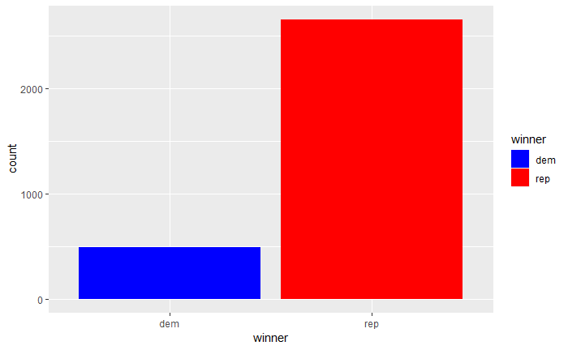

```r
# create bar plot
data %>% mutate (winner = c("dem","rep")[rep+1]) %>%
  ggplot()+aes(x=winner, fill=winner)+geom_bar()+scale_fill_manual(values=c("blue","red"))
```

# Machine learning models

First we will partition the data in a train dataset and a test dataset

```r
# set the seed for reproducibility
set.seed(seed)
# select the indexes of the rows in the training set
train.index <- createDataPartition(
  data$rep, p = .8,
  list = FALSE,
  times = 1)
# split the data
train.data <- data[ train.index,]
test.data  <- data[-train.index,]
```

As it seems that we are dealing with unbalanced data, we may want to balance them using the ROSE package.

```r
mean(test.data$rep)
```

```
[1] 0.8343949
```

```r
# oversampling method to balance training set
# we tried with and without and it greatly improves the results
train.data.balanced <- ovun.sample(rep ~ ., data = data, method = "over")$data

train.y <-  train.data.balanced[,2]
train <- train.data.balanced[, -c(1:4)]

test.y <-  test.data[,2]
test <- test.data[, -c(1:4)]
```

```r
mean(train.y)
```

```
[1] 0.4992473
```

## Logistic models

The first model that we could try is a logistic regression, given that we are on a binary classification problem

```r
# train logit model
logit <- glm(train.y~., data = train, family = binomial)
summary(logit)
```

```
Call:
glm(formula = train.y ~ ., family = binomial, data = train)

Deviance Residuals:
    Min       1Q   Median       3Q      Max
-2.9199  -0.2364   0.0000   0.1830   4.8854

Coefficients:
              Estimate Std. Error z value Pr(>|z|)
(Intercept)  4.918e+01  7.980e+01   0.616 0.537658
PST045214   -1.734e-05  1.792e-05  -0.967 0.333354
PST040210   -3.023e-04  3.457e-04  -0.874 0.381988
PST120214    8.683e-02  2.303e-02   3.771 0.000163 ***
POP010210    3.290e-04  3.454e-04   0.953 0.340813
AGE135214   -5.316e-01  1.272e-01  -4.181 2.91e-05 ***
AGE295214    4.337e-01  5.455e-02   7.951 1.86e-15 ***
AGE775214    2.301e-01  3.332e-02   6.905 5.03e-12 ***
SEX255214   -4.706e-02  3.484e-02  -1.351 0.176839
RHI125214   -5.689e-01  7.952e-01  -0.715 0.474408
RHI225214   -4.160e-01  7.976e-01  -0.522 0.601955
RHI325214   -4.502e-01  7.972e-01  -0.565 0.572269
RHI425214   -3.426e-01  7.998e-01  -0.428 0.668406
RHI525214   -3.380e-01  8.632e-01  -0.392 0.695363
RHI625214   -1.251e-01  8.032e-01  -0.156 0.876224
RHI725214    1.678e-01  8.349e-02   2.010 0.044478 *
RHI825214    2.799e-01  8.949e-02   3.128 0.001761 **
POP715213   -1.995e-01  2.079e-02  -9.600  < 2e-16 ***
POP645213    4.406e-02  2.726e-02   1.616 0.106032
POP815213   -7.362e-02  1.862e-02  -3.953 7.72e-05 ***
EDU635213   -1.495e-01  2.118e-02  -7.059 1.67e-12 ***
EDU685213   -1.399e-01  1.681e-02  -8.321  < 2e-16 ***
VET605213    7.905e-05  2.355e-05   3.357 0.000788 ***
LFE305213   -4.396e-02  1.889e-02  -2.327 0.019986 *
HSG010214    5.017e-05  1.364e-05   3.677 0.000236 ***
HSG445213   -1.382e-02  1.477e-02  -0.936 0.349460
HSG096213   -7.560e-02  1.479e-02  -5.110 3.22e-07 ***
HSG495213   -2.459e-05  2.057e-06 -11.957  < 2e-16 ***
HSD410213   -1.273e-04  2.310e-05  -5.508 3.63e-08 ***
HSD310213    3.529e+00  5.181e-01   6.811 9.72e-12 ***
INC910213    2.219e-04  4.368e-05   5.079 3.80e-07 ***
```

[output cut: 16 more lines]

```
RTN131207   -1.645e-05  1.555e-05  -1.058 0.289969
AFN120207   -1.476e-06  5.204e-07  -2.837 0.004555 **
BPS030214    3.467e-04  1.681e-04   2.062 0.039199 *
LND110210    2.942e-04  4.774e-05   6.163 7.15e-10 ***
POP060210    1.082e-04  1.698e-04   0.637 0.524262
---
Signif. codes:  0 ‘***’ 0.001 ‘**’ 0.01 ‘*’ 0.05 ‘.’ 0.1 ‘ ’ 1

(Dispersion parameter for binomial family taken to be 1)

    Null deviance: 7366.8  on 5313  degrees of freedom
Residual deviance: 2213.2  on 5262  degrees of freedom
AIC: 2317.2

Number of Fisher Scoring iterations: 10
```

In the output of the model we see that all the variable are not statistically significant. Therefore, before estimating the risk of the model we will try to create smaller models with features selection techniques. Then we will be able to compare the results of those models.

```r
# let's limit the max number of features (for readability purpose)
max.features <- 20
# we create a function to get the selected variables from a regsubsets
sel.subset <- function (regsubset, nb.features) {
  subsets <- summary(regsubset)
  var.sel <- subsets$which[nb.features,][-1]
  var.sel <- names(var.sel)[var.sel] %>% paste(collapse="+")
  return(formula(paste("train.y~",var.sel,sep="")))
}
```

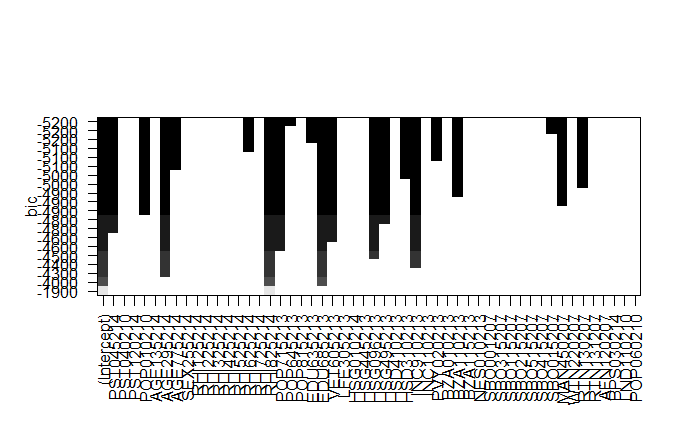

```r
# we select the best subset variables with the backward method
sel.back <- regsubsets(train.y~., data=train, really.big = T,
                       nvmax=max.features, method="backward")
# we display the BIC selection
plot(sel.back, scale="bic")
```

```r
# we create a new logit model based on this variable selection
logit.back <- glm(sel.subset(sel.back, 12), data=train)
# we output the model
summary(logit.back)
```

```
Call:
glm(formula = sel.subset(sel.back, 12), data = train)

Deviance Residuals:
     Min        1Q    Median        3Q       Max
-0.94611  -0.20841  -0.01035   0.20207   1.09011

Coefficients:
              Estimate Std. Error t value Pr(>|t|)
(Intercept)  6.254e-01  9.917e-02   6.306 3.09e-10 ***
PST045214    2.923e-06  2.920e-07  10.009  < 2e-16 ***
POP010210   -2.725e-06  2.997e-07  -9.090  < 2e-16 ***
AGE295214    2.165e-02  1.316e-03  16.449  < 2e-16 ***
RHI825214    1.164e-02  2.226e-04  52.287  < 2e-16 ***
POP715213   -1.394e-02  1.109e-03 -12.572  < 2e-16 ***
EDU685213   -2.481e-02  8.278e-04 -29.973  < 2e-16 ***
VET605213   -6.891e-06  4.756e-07 -14.488  < 2e-16 ***
HSG096213   -7.448e-03  5.700e-04 -13.066  < 2e-16 ***
HSG495213   -6.057e-07  7.116e-08  -8.511  < 2e-16 ***
INC910213    2.476e-05  1.414e-06  17.510  < 2e-16 ***
BZA110213    3.123e-07  6.485e-08   4.815 1.51e-06 ***
MAN450207   -7.193e-09  7.919e-10  -9.083  < 2e-16 ***
---
Signif. codes:  0 ‘***’ 0.001 ‘**’ 0.01 ‘*’ 0.05 ‘.’ 0.1 ‘ ’ 1

(Dispersion parameter for gaussian family taken to be 0.09672423)

    Null deviance: 1328.50  on 5313  degrees of freedom
Residual deviance:  512.74  on 5301  degrees of freedom
AIC: 2682.5

Number of Fisher Scoring iterations: 2
```

Let’s do the same thing with the forward selection method

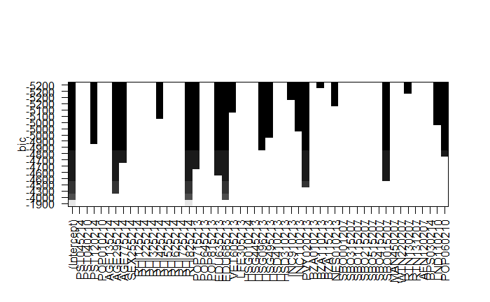

```r
# we select the best subset variables with the forward method
sel.forw <- regsubsets(train.y~., data=train, really.big = T, nvmax=max.features, method="forward")
# we display the BIC selection
plot(sel.forw, scale="bic")
```

Same conclusion, we can safely remove most features and keep the 12 selected by the forward selection method.

```r
# we create the logit model based on this variable selection
logit.forw <- glm(sel.subset(sel.forw, 12), data = train, family = binomial)
```

[output not shown]

```r
# we output the model
summary(logit.forw)
```

```
Call:
glm(formula = sel.subset(sel.forw, 12), family = binomial, data = train)

Deviance Residuals:
    Min       1Q   Median       3Q      Max
-2.8632  -0.2945   0.0000   0.2631   4.2019

Coefficients:
              Estimate Std. Error z value Pr(>|z|)
(Intercept)  1.227e+01  1.579e+00   7.770 7.85e-15 ***
PST120214    7.314e-02  1.643e-02   4.452 8.50e-06 ***
AGE295214    2.955e-01  2.174e-02  13.592  < 2e-16 ***
AGE775214    1.049e-01  1.855e-02   5.654 1.57e-08 ***
RHI825214    1.033e-01  4.522e-03  22.839  < 2e-16 ***
POP715213   -1.518e-01  1.508e-02 -10.063  < 2e-16 ***
EDU635213   -7.408e-02  1.280e-02  -5.789 7.08e-09 ***
EDU685213   -1.124e-01  1.123e-02 -10.003  < 2e-16 ***
HSG096213   -9.280e-02  9.666e-03  -9.601  < 2e-16 ***
HSG495213   -8.735e-06  1.168e-06  -7.481 7.37e-14 ***
PVY020213   -1.386e-01  1.171e-02 -11.836  < 2e-16 ***
SBO015207   -2.946e-02  4.772e-03  -6.173 6.71e-10 ***
POP060210   -1.814e-04  1.518e-04  -1.195    0.232
---
Signif. codes:  0 ‘***’ 0.001 ‘**’ 0.01 ‘*’ 0.05 ‘.’ 0.1 ‘ ’ 1

(Dispersion parameter for binomial family taken to be 1)

    Null deviance: 7366.8  on 5313  degrees of freedom
Residual deviance: 2614.0  on 5301  degrees of freedom
AIC: 2640

Number of Fisher Scoring iterations: 8
```

Now we have created 3 logistic model we may compare them by calculating the mean square error on the test dataset

```r
# function to transform a score into a prediction for a given thresold
# if value > threshold, then the predicted value is 1 else it's 0
score.pred <- function (value, threshold = 0.5) {
  return(ifelse(value > threshold, 1, 0))
}
# let's define an arbirary threshold
t <- 0.5
# let's calculate the MSE for the given thresold (t=0.5)
p.full  <- predict( logit,      newdata = test, type = "response")
p.back  <- predict( logit.back, newdata = test, type = "response")
p.forw  <- predict( logit.forw, newdata = test, type = "response")
pred.log <- data.frame(
  logit.full=p.full,
  logit.back=p.back,
  logit.forw=p.forw,
  obs=test.y
  )
pred.log %>%
  select(-obs) %>%
  summarise_all(funs( mean( (score.pred(., t) - test.y)^2 ) )) %>%
  setNames(paste0('MSE.', names(.)))
```

| MSE.logit.full | MSE.logit.back | MSE.logit.forw |
| --- | --- | --- |
| 0.07324841 | 0.09872611 | 0.08757962 |

In this case the logit model based on all the variables seems to have a lower estiamted risk than the smaller models. As the thresold was arbitrary, we might want to check if it would also be the case for any other threshold. In order to do that, let’s draw the ROC curve and then calculate the are under (the ROC) curve

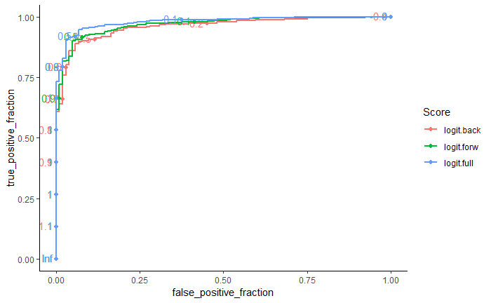

```r
df.log <- pred.log %>% gather(key="Score",value="value",-obs)
ggplot(df.log)+aes(d=obs,m=value,color=Score)+geom_roc()+theme_classic()
```

```r
pred.log %>% select(-obs) %>% summarise_all(funs(auc(test.y, .))) %>% setNames(paste0('AUC.', names(.)))
```

| AUC.logit.full | AUC.logit.back | AUC.logit.forw |
| --- | --- | --- |
| 0.9799435 | 0.960988 | 0.9688417 |

The full logit model still perform better than the two other features. Then, from now on, we will based all our new models on all the features.

## Logistic lasso & ridge models

Let’s try the lasso and the ridge model. We will use the cv.glmnet instead of the glmnet function to find the best lambda by 10-fold cross validation

```r
train.mat <- model.matrix(train.y~., data=train)
test.mat <- model.matrix(test.y~., data=test)
lasso <- cv.glmnet(train.mat, train.y, family="binomial", alpha=1)
ridge <- cv.glmnet(train.mat, train.y, family="binomial", alpha=0)
```

We can now compare those two new models with the previous logit model

```r
p.lasso <- predict( lasso, newx = test.mat, type = "response") %>% as.vector()
p.ridge <- predict( ridge, newx = test.mat, type = "response") %>% as.vector()
pred.flr <- data.frame(logit.full=p.full, lasso=p.lasso, ridge=p.ridge, obs=test.y)
pred.flr %>% select(-obs) %>% summarise_all(funs( mean( (score.pred(., t) - test.y)^2 ) )) %>% setNames(paste0('MSE.', names(.)))
```

| MSE.logit.full | MSE.lasso | MSE.ridge |
| --- | --- | --- |
| 0.07324841 | 0.07643312 | 0.08280255 |

Here is the ROC plot

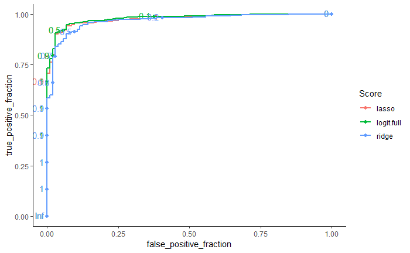

```r
df.flr <- pred.flr %>% gather(key="Score",value="value",-obs)
ggplot(df.flr)+aes(d=obs,m=value,color=Score)+geom_roc()+theme_classic()
```

On the ROC plot it is difficult to say which model is the best so let’s calculate the AUC for each model

```r
pred.flr %>% select(-obs) %>% summarise_all(funs(auc(test.y, .))) %>% setNames(paste0('AUC.', names(.)))
```

| AUC.logit.full | AUC.lasso | AUC.ridge |
| --- | --- | --- |
| 0.9799435 | 0.9758881 | 0.9678692 |

In the end, the logit model is still the best model so far

## Tree

We will now try to build different trees

First, here is a simple tree

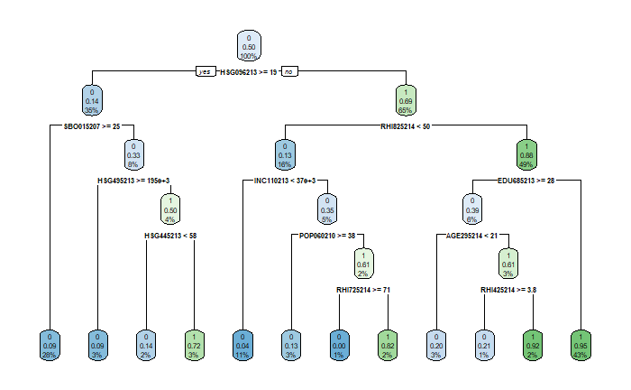

```r
set.seed(seed)
train.y.factor <- as.factor(train.y)
large.tree <- rpart(train.y.factor~., data=train, cp=5.0e-3)
rpart.plot(large.tree)
```

Now let’s build a simplier tree from the previous one

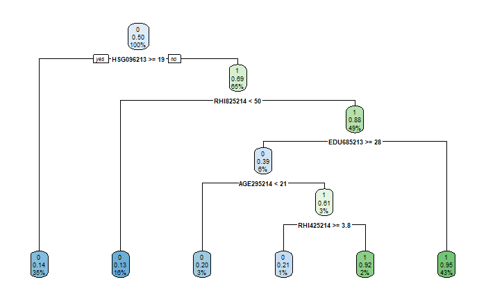

```r
set.seed(seed)
opt.tree <- prune(large.tree, cp=cp_opt)
simple.tree <- prune(large.tree, cp=0.01)
rpart.plot(simple.tree)
```

Now let’s create a tree with the optimal complexity

```r
# find optimal CP
cp_opt <- large.tree$cptable %>%
  as.data.frame() %>%
  filter(xerror==min(xerror)) %>%
  dplyr::select(CP) %>%
  as.numeric()

# print CP
printcp(large.tree)

# prune tree with the optimal cp
opt.tree <- prune(large.tree, cp=cp_opt)
```

[output not shown]

Let’s compare the results of those three machines

```r
p.simple.tree = predict(simple.tree, newdata = test)[,2]
p.large.tree  = predict(large.tree,  newdata = test)[,2]
p.opt.tree    = predict(opt.tree,    newdata = test)[,2]
pred.stree <- data.frame(
  simple.tree = p.simple.tree,
  large.tree  = p.large.tree,
  opt.tree    = p.opt.tree
  )
pred.stree %>% summarise_all(funs(mean((score.pred(., t) - test.y)^2))) %>% setNames(paste0('MSE.', names(.)))
```

| MSE.simple.tree | MSE.large.tree | MSE.opt.tree |
| --- | --- | --- |
| 0.1321656 | 0.0955414 | 0.0955414 |

Those trees show poor results in comparison to the logit model, so let’s try another model

We will try to build a Random Forest which uses a Boostrap Aggregating method to improve the stability and the accuracy of our tree that are not very performant

```r
set.seed(seed)
forest <- randomForest(train.y.factor~.,data=train)
forest
```

```
Call:
 randomForest(formula = train.y.factor ~ ., data = train)
               Type of random forest: classification
                     Number of trees: 500
No. of variables tried at each split: 7

        OOB estimate of  error rate: 1.6%
Confusion matrix:
     0    1 class.error
0 2657    4 0.001503194
1   81 2572 0.030531474
```

Now let’s compare the results with the previous trees

```r
p.forest = predict(forest, newdata = test, type="prob")[,2]
pred.trees <- data.frame(
  simple.tree = p.simple.tree,
  large.tree  = p.large.tree,
  opt.tree    = p.opt.tree,
  forest      = p.forest,
  obs         = test.y
)
pred.trees %>% select(-obs) %>% summarise_all(funs(mean((score.pred(., t) - test.y)^2))) %>% setNames(paste0('MSE.', names(.)))
```

| MSE.simple.tree | MSE.large.tree | MSE.opt.tree | MSE.forest |
| --- | --- | --- | --- |
| 0.1321656 | 0.0955414 | 0.0955414 | 0 |

Wouw! Perfect score! Let’s check the ROC curve

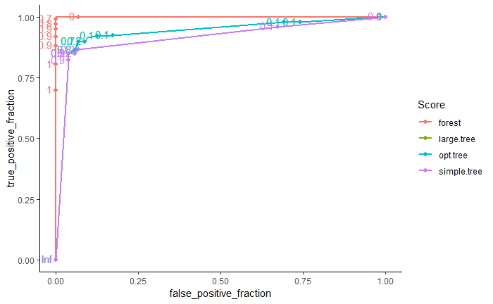

```r
df.trees <- pred.trees %>% gather(key="Score",value="value",-obs)
ggplot(df.trees)+aes(d=obs,m=value,color=Score)+geom_roc()+theme_classic()
```

And now the AUC

```r
pred.trees %>% select(-obs) %>% summarise_all(funs(auc(test.y, .))) %>% setNames(paste0('AUC.', names(.)))
```

| AUC.simple.tree | AUC.large.tree | AUC.opt.tree | AUC.forest |
| --- | --- | --- | --- |
| 0.9139386 | 0.9363164 | 0.9363164 | 1 |

That’s indeed a perfect score…

```r
forest.pred.factor <- as.factor(score.pred(pred.trees$forest, t))
obs.factor <- as.factor(test.y)
confusionMatrix(forest.pred.factor, obs.factor)
```

```
Confusion Matrix and Statistics

          Reference
Prediction   0   1
         0 104   0
         1   0 524

               Accuracy : 1
                 95% CI : (0.9941, 1)
    No Information Rate : 0.8344
    P-Value [Acc > NIR] : < 2.2e-16

                  Kappa : 1
 Mcnemar's Test P-Value : NA

            Sensitivity : 1.0000
            Specificity : 1.0000
         Pos Pred Value : 1.0000
         Neg Pred Value : 1.0000
             Prevalence : 0.1656
         Detection Rate : 0.1656
   Detection Prevalence : 0.1656
      Balanced Accuracy : 1.0000

       'Positive' Class : 0
```

## Bonus: XGBoost

Let’s train the model

```r
train.matrix <- xgb.DMatrix(label = as.matrix(train.y), data = as.matrix(train))
test.matrix  <- xgb.DMatrix(label = as.matrix(test.y),  data = as.matrix(test))
xgboost <- xgboost(
  data = train.matrix,
  nrounds = 10,
  objective = "binary:logistic",
  verbose = 0
  )
```

And check the results

```r
pred.xgb <- data.frame(
  forest      = predict(forest,  newdata = test, type="prob")[,2],
  xgboost     = predict(xgboost, test.matrix),
  obs         = test.y
)
# MSE
pred.xgb %>% select(-obs) %>% summarise_all(funs(mean((score.pred(., t) - test.y)^2))) %>% setNames(paste0('MSE.', names(.)))
```

| MSE.forest | MSE.xgboost |
| --- | --- |
| 0 | 0.0111465 |

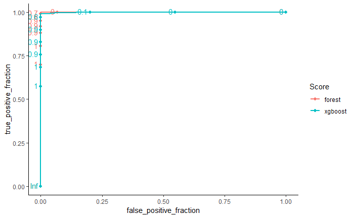

```r
# ROC
df.xgb <- pred.xgb %>% gather(key="Score",value="value",-obs)
ggplot(df.xgb)+aes(d=obs,m=value,color=Score)+geom_roc()+theme_classic()
```

```r
# AUC
pred.xgb %>% select(-obs) %>% summarise_all(funs(auc(test.y, .))) %>% setNames(paste0('AUC.', names(.)))
```

| AUC.forest | AUC.xgboost |
| --- | --- |
| 1 | 0.9994128 |

```r
# Confusion matrix
forest.pred.factor <- as.factor(score.pred(predict(xgboost, test.matrix), t))
confusionMatrix(forest.pred.factor, obs.factor)
```

```
Confusion Matrix and Statistics

          Reference
Prediction   0   1
         0 104   7
         1   0 517

               Accuracy : 0.9889
                 95% CI : (0.9772, 0.9955)
    No Information Rate : 0.8344
    P-Value [Acc > NIR] : < 2e-16

                  Kappa : 0.9607
 Mcnemar's Test P-Value : 0.02334

            Sensitivity : 1.0000
            Specificity : 0.9866
         Pos Pred Value : 0.9369
         Neg Pred Value : 1.0000
             Prevalence : 0.1656
         Detection Rate : 0.1656
   Detection Prevalence : 0.1768
      Balanced Accuracy : 0.9933

       'Positive' Class : 0
```

The results are pretty good given that we trained our XGBoost algorithm on only 10 rounds whereas the RandomForest was built on 500 trees !